# Card 데이터 분석

### 군집들의 공휴일/주중주말 오픈 유무값 - 평균값

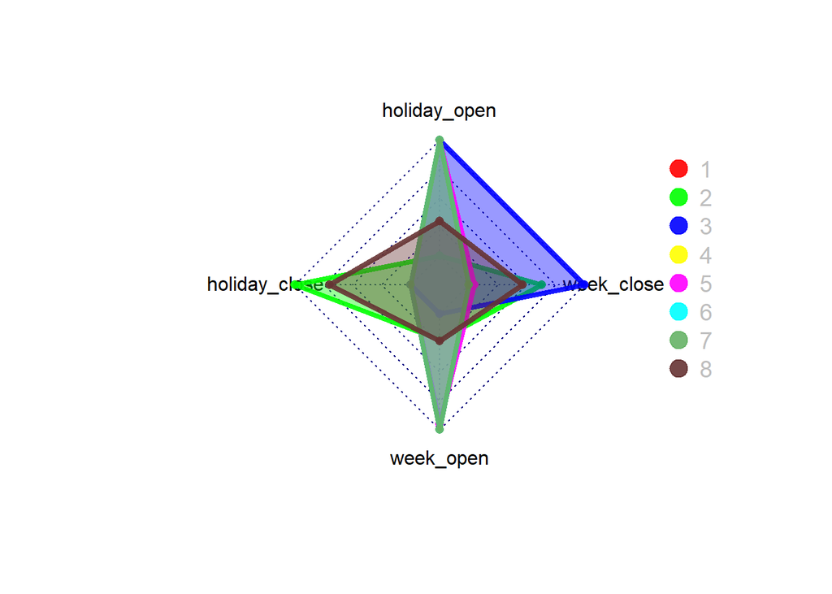

```r
g_mean2 <- df_radarchart(scale(g_mean[,c(5,6,7,8)]))

radarchart(g_mean2,pfcol=colors_in, pcol=colors_border, plwd=4 , plty=1 )

legend(x=1.5, y=1, legend = rownames(g_mean2[-c(9,10),]), bty = "n", pch=20 ,text.col = "grey", cex=1.2, pt.cex=3,col=colors_border)
```

### 군집들의 시간대별 특징값 - 평균값

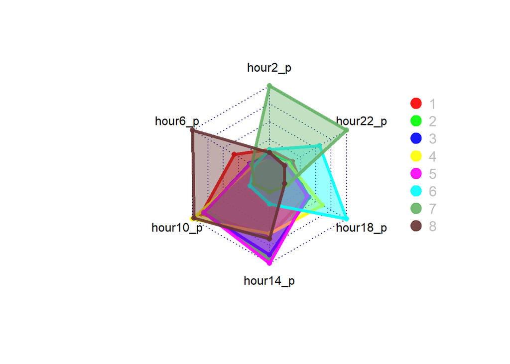

```r
g_mean3 <- df_radarchart(scale(g_mean[,c(11:16)]))

radarchart(g_mean3,pfcol=colors_in, pcol=colors_border, plwd=4 , plty=1 )

legend(x=1.5, y=1, legend = rownames(g_mean3[-c(9,10),]), bty = "n", pch=20 ,text.col = "grey", cex=1.2, pt.cex=3,col=colors_border)
```

## 중앙값(g_median)

### 군집들의 일반적(거래내역) 특징 - 중앙값

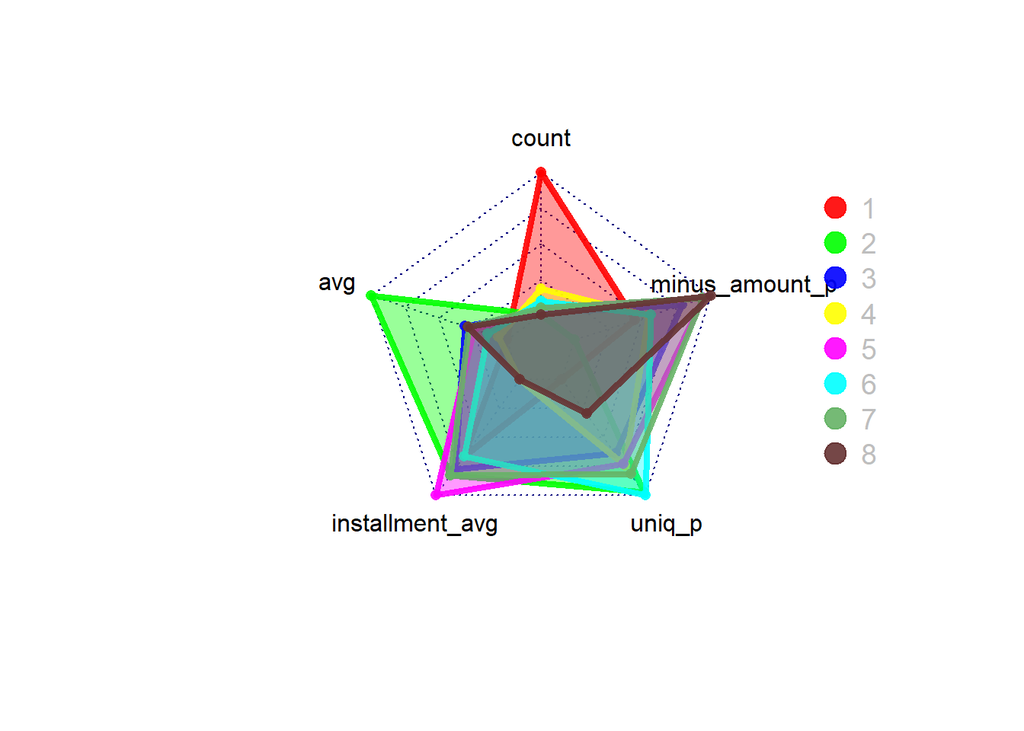

```r
g_median1 <- df_radarchart(scale(g_median[,c(2,3,4,9,10)]))

radarchart(g_median1,pfcol=colors_in, pcol=colors_border, plwd=4 , plty=1 )

legend(x=1.5, y=1, legend = rownames(g_median1[-c(9,10),]), bty = "n", pch=20 ,text.col = "grey", cex=1.2, pt.cex=3,col=colors_border)
```

### 군집들의 공휴일/주중주말 오픈 유무 - 중앙값

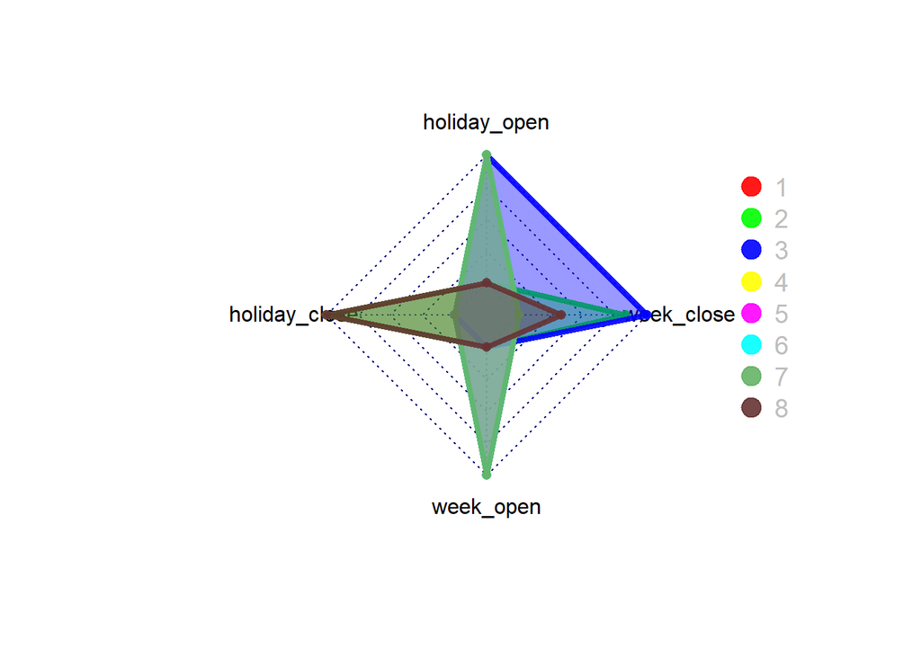

```r
g_median2 <- df_radarchart(scale(g_median[,c(5,6,7,8)]))

radarchart(g_median2,pfcol=colors_in, pcol=colors_border, plwd=4 , plty=1 )

legend(x=1.5, y=1, legend = rownames(g_median2[-c(9,10),]), bty = "n", pch=20 ,text.col = "grey", cex=1.2, pt.cex=3,col=colors_border)
```

### 군집들의 시간대별 특징 - 중앙값

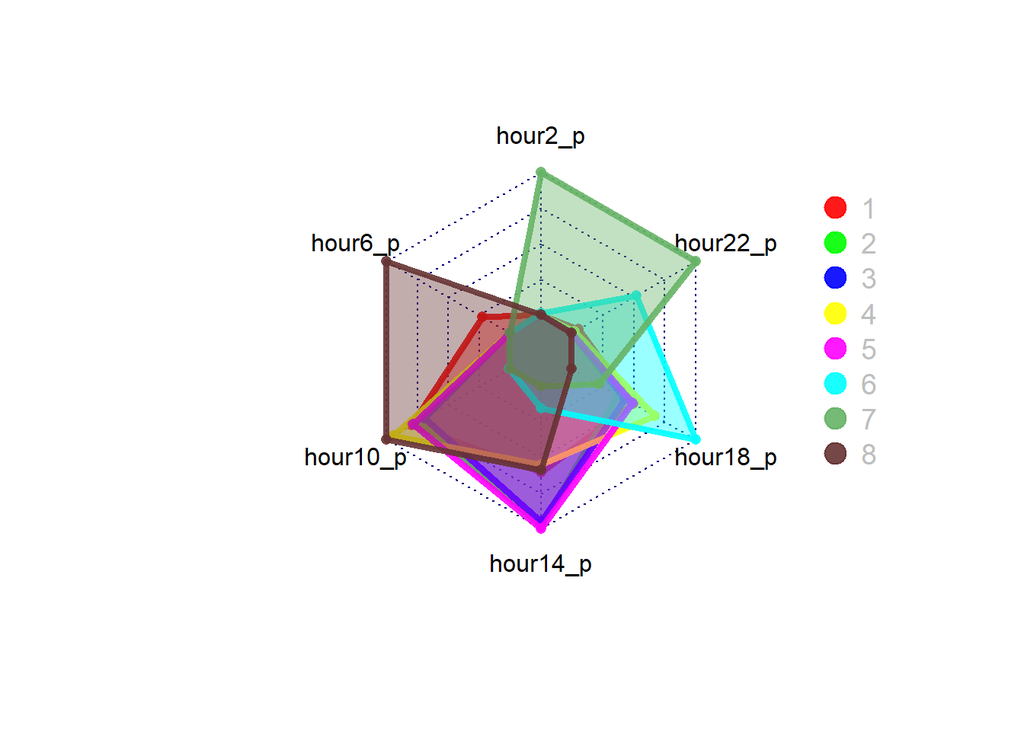

```r
g_median3 <- df_radarchart(scale(g_median[,c(11:16)]))

radarchart(g_median3,pfcol=colors_in, pcol=colors_border, plwd=4 , plty=1 )

legend(x=1.5, y=1, legend = rownames(g_median3[-c(9,10),]), bty = "n", pch=20 ,text.col = "grey", cex=1.2, pt.cex=3,col=colors_border)
```

## 평균값으로 봤을때의 특징 vs 중앙값으로 보았을때의 특징

### 군집들의 일반적(거래내역) 특징 - 평균값 vs 중앙값

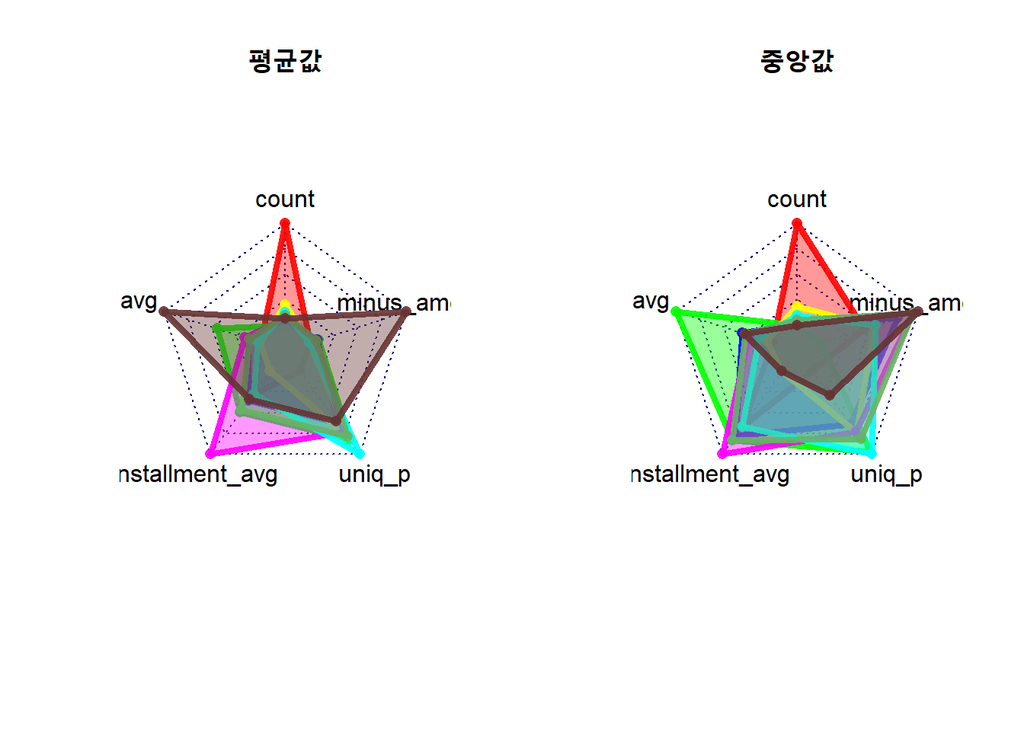

```r
par(mfrow= c(1,2))
radarchart(g_mean1,pfcol=colors_in, pcol=colors_border, plwd=4 , plty=1, title = "평균값" )
radarchart(g_median1,pfcol=colors_in, pcol=colors_border, plwd=4 , plty=1, title = "중앙값" )
```

### 군집들의 공휴일/주중주말 오픈 유무 - 평균값 vs 중앙값

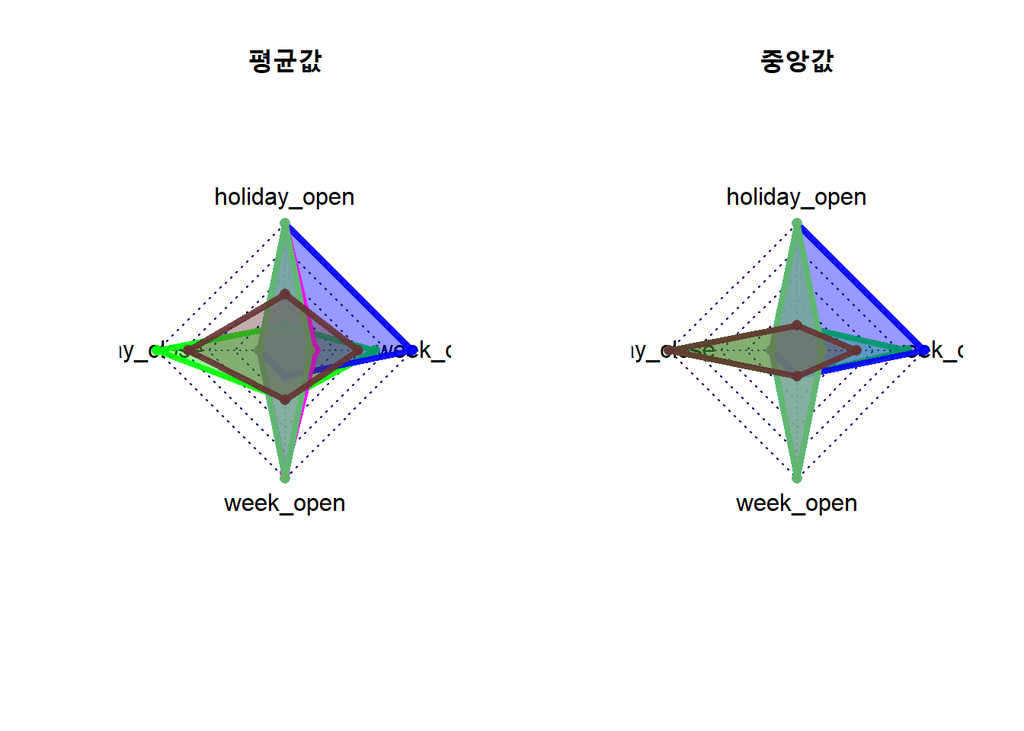

```r
par(mfrow= c(1,2))
radarchart(g_mean2,pfcol=colors_in, pcol=colors_border, plwd=4 , plty=1, title = "평균값" )
radarchart(g_median2,pfcol=colors_in, pcol=colors_border, plwd=4 , plty=1, title = "중앙값" )
```

### 군집들의 시간대별 특징 - 평균값 vs 중앙값

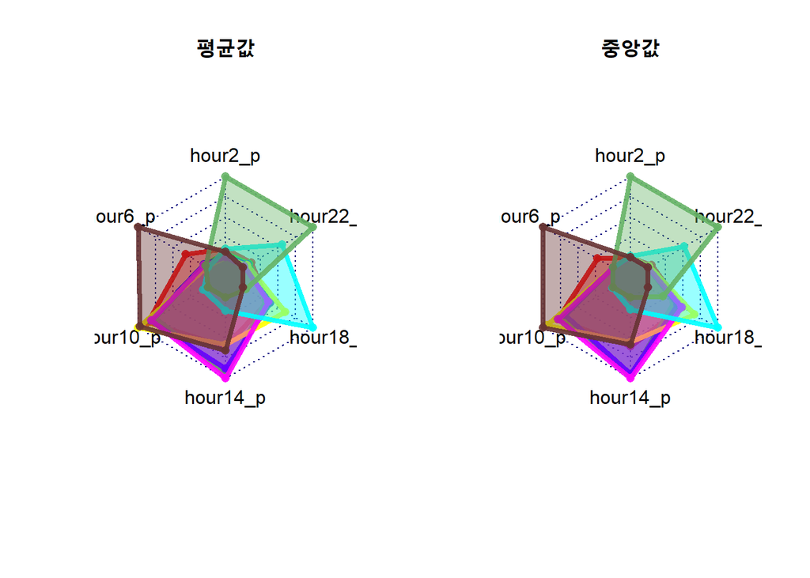

```r
par(mfrow= c(1,2))
radarchart(g_mean3,pfcol=colors_in, pcol=colors_border, plwd=4 , plty=1, title = "평균값" )
radarchart(g_median3,pfcol=colors_in, pcol=colors_border, plwd=4 , plty=1, title = "중앙값")
```

### 레이더 차트의 개형이 비슷한 경우

- 군집들의 공휴일/주중주말 오픈 유무
- 군집들의 시간대별 특징 - 평균값 vs 중앙값

### 레이더 차트의 개형이 다른 경우

- 군집들의 일반적(거래내역) 특징 - 평균값 vs 중앙값

### 즉, 일반적(거래내역)의 차이만 조금 보정해가면서 군집들을 예측해보자.

# 8_군집예측

## 군집별 특징 정리 및 예측

### 1군집 예측: 편의점, 카페/베이커리

1.거래빈도(count)가 매우 많음

2.평균거래가격(avg)가 매우낮음

4.공휴일 open

5.주말 open

6.10시~18시 고르게 분포

### 2군집 예측: 병원/의료/약품

1.거래빈도(count)가 매우 적음

2.평균거래가격(avg)가 높음

4.환불(minus_amount_p)을 하지않음 - (중앙값에서만 나타남)

5.공휴일 close

6.(대부분)주말 close

1위: 14시~18시

2위: 10시~14시, 18시~22시

### 3군집 예측: 가정생활/서비스/기타

1.거래빈도(count)가 적음 - (중앙값에서만 나타남)

2.공휴일 open

3.주말 close

4.1위: 14시~18시

5.2위: 10시~14시, 18시~22시

### 4군집 예측: 식당(한식/일식/중식/양식/패스트푸드)

1.거래빈도(count)가 많음

2.평균거래가격(avg)이 매우낮음

3.평균할부개월수(installment_avg)가 매우 낮음

4.환불비율(minus_amount_p)이 낮음

5.공휴일 open

6.주말 open

7.1위: 18시~22시

8.2위: 10시~14시

9.3위: 14시~18시

### 5군집 예측: 서점/문구, 학원/교육

1.평균할부개월수(installment_avg)가 매우 높음

2.공휴일 open

3.주말 open

4.1위: 14시~18시(42%)

5.2위: 10시~14시, 18시~22시

### 6군집 예측: 주유소, 미용/뷰티

1.평균거래가격(avg)이 낮음

3.환불(minus_amount_P)비율이 낮음 - (중앙값에서만 나타남)

4.공휴일 open

5.주말 open

6.1위: 18시~22시(52%)

7.2위: 22시~2시

### 7군집 예측: 유흥(술집, 클럽), 유통(도매시장)

2.공휴일 open

3.주말 open

4.1위: 22시~2시(60%)

5.2위: 2시~6시

### 8군집 예측: 귀금속(?)중앙값과 평균값의 차이가 많은것으로 보아 분포가 다양함을 알 수 있다. 여러 업종이 섞였을 가능성이 많다.

1.평균거래가격(avg)가 매우 높음 - (평균값에서만 나타남)

2.환불비율(minus_amount_p)이 매우매우높음

3.거래빈도(count)가 매우매우 적음 - (중앙값에서만 나타남)

4.할부(installment_avg)를 하지 않음 - (중앙값에서만 나타남)

6.공휴일 open/close반반

7.(대부분)주말 close

8.1위: 10시~14시

9.2위: 14시~18시

10.3위: 6시~10시

11.4위: 18시~22시